# ReproducibilityAssessment1

James Sidell

Sunday, November 16, 2014

```r
options(scipen=1, digits=2)
```

## Load the data first

I’ll use dplyr so I can group by the date easily. echo=TRUE throughout this document (I’m not hiding anything. I promise).

```r
library(dplyr)
setwd("C:/Users/James/Dropbox/DataScience/Reprod")
rawData <- read.csv("repdata/activity.csv")
head(rawData)
```

[output not shown]

## Preprocess the data

Remove ‘NAs’ for initial work, make a histogram of total steps per day, and calculate summary values for each day.

```r
cleanData <- rawData[complete.cases(rawData),]
summaryData <- summarise(group_by(cleanData,date),
                        n=sum(steps),
                        m=mean(steps),
                        med=median(steps))
meanTotal <- mean(summaryData$n)
medianTotal <- median(summaryData$n)
```

Mean of total steps is 10766.19.

Median of total steps is 10765.

A histogram of the total steps per day is shown below:

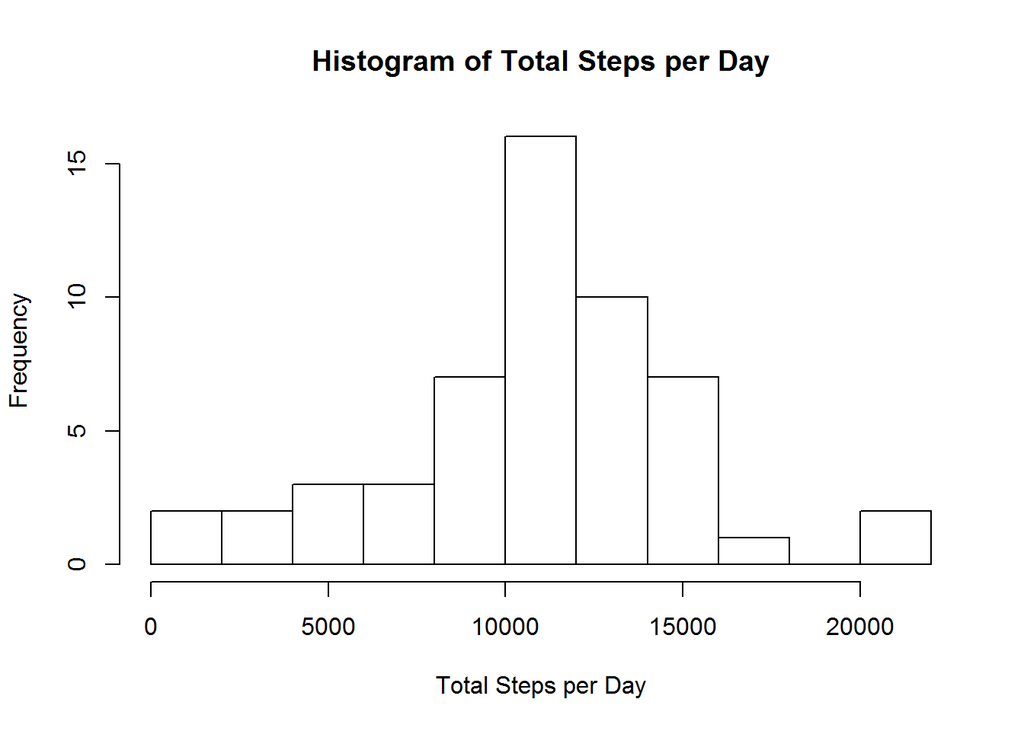

```r
hist(summaryData$n, main="Histogram of Total Steps per Day", xlab="Total Steps per Day", breaks=10)
```

## Average Daily Activity Pattern

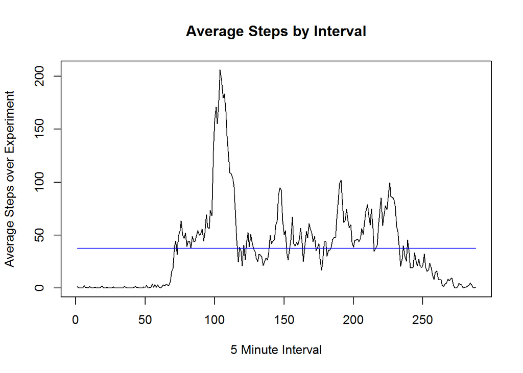

```r
intervalAverage <- summarise(group_by(cleanData,interval),
                             mean=mean(steps))
plot(intervalAverage$mean,type="l", main="Average Steps by Interval",xlab="5 Minute Interval", ylab="Average Steps over Experiment")
lines(rep(mean(intervalAverage$mean),length(intervalAverage$interval)),col="blue")
```

```r
maxInterval <- intervalAverage[intervalAverage$mean==max(intervalAverage$mean),]
hours <- (maxInterval-(maxInterval %% 60))/60
minutes <- (maxInterval %% 60)
```

## Input Missing Values

```r
  summary(complete.cases(rawData))
```

```
##    Mode   FALSE    TRUE    NA's
## logical    2304   15264       0
```

```r
  data <- group_by(rawData, interval)
  interval <- group_by(intervalAverage, interval)

  imputate <- seq(1, nrow(data))
  for (i in 1:nrow(data)){
    imputate[i] = intervalAverage[intervalAverage$interval==data$interval[i],2]
  }
  data <- cbind(data, imputate)

  synthData <- mutate(data, synth=ifelse(!is.na(steps), steps,imputate))
  synthData <- synthData[, c("date", "interval", "synth")]
  head(synthData)
```

```
##         date interval synth
## 1 2012-10-01        0 1.717
## 2 2012-10-01        5 0.340
## 3 2012-10-01       10 0.132
## 4 2012-10-01       15 0.151
## 5 2012-10-01       20 0.075
## 6 2012-10-01       25 2.094
```

From the summary of the complete.cases output we can see there are 2304 values of NA in the data set that need to be replaced.

Replacing the data is trickier. There could be a long discussion about exactly how to do it, so I will simply replace the values for each missing interval with the mean for that interval over the course of the experiment. This data will come from the intervalAverage table I created earlier. I really hated to put a for loop in there, but I kept running into problems trying to use mutate only to pull the necessary value from the intervalAverage table. The new data table produced is named synthData, and a brief summary is shown above.

```r
  synthSummary <- summarise(group_by(synthData, date), n=sum(synth), m=mean(synth), med=median(synth))

meanSynthDay <- mean(synthSummary$n)
medianSynthDay <- median(synthSummary$n)
```

Mean of total steps is 10766.19.

Median of total steps is 10766.19.

A histogram of the total steps per day is shown below:

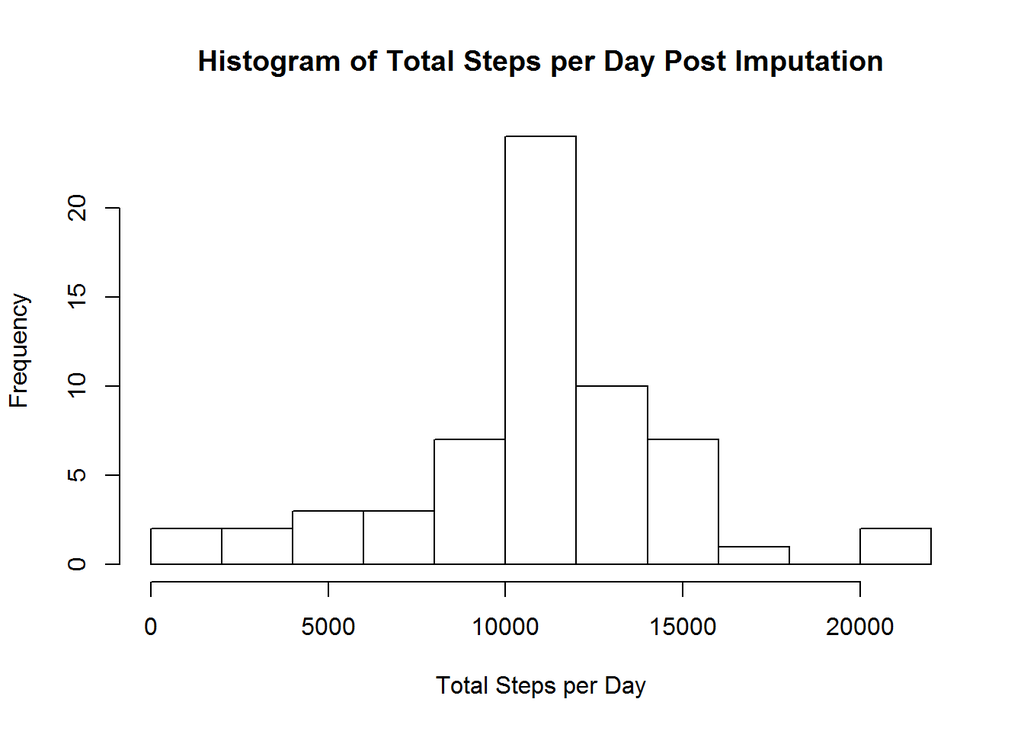

```r
hist(synthSummary$n, main="Histogram of Total Steps per Day Post Imputation", xlab="Total Steps per Day", breaks=10)
```

It turns out the histogram isn’t that much different than before. The mean is roughly the same, and the median is just slightly higher than before. This is to be expected, however, since I used the mean values for the interval. Adding values that were already a part of the distribution shouldn’t have affected much, although it did increase the size of the unnormalized histogram above.

## Weekdays vs Weekend Analysis

Here I mutated the dataset to add a column with the name of the day and whether the day was a “weekday” or “weekend”.

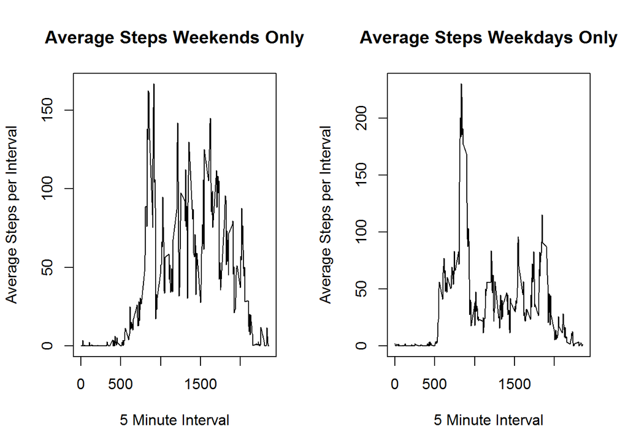

[output not shown]

```r
  synthData <- mutate(synthData, weekday=weekdays(as.POSIXct(date)))
  synthData <- mutate(synthData, weekend=ifelse(weekday=="Sunday" | weekday=="Saturday","weekend","weekday"))
  synthSummary <- summarise(group_by(synthData, interval, weekend), intMean=mean(synth))

  weekendData <- synthSummary[synthSummary$weekend=="weekend",]
  weekdayData <- synthSummary[synthSummary$weekend=="weekday",]

  par(mfrow=c(1,2))
  plot(weekendData$interval, weekendData$intMean,type="l", main="Average Steps Weekends Only",xlab="5 Minute Interval", ylab="Average Steps per Interval")

  plot(weekdayData$interval, weekdayData$intMean,type="l", main="Average Steps Weekdays Only",xlab="5 Minute Interval", ylab="Average Steps per Interval")
```